# Logistic regression

Joshua Loftus

2/5/2021

## Categorical outcome data

Look at this data

```r
head(attrition)
```

```
##   Age Attrition    BusinessTravel DailyRate           Department
## 1  41       Yes     Travel_Rarely      1102                Sales
## 2  49        No Travel_Frequently       279 Research_Development
## 4  37       Yes     Travel_Rarely      1373 Research_Development
## 5  33        No Travel_Frequently      1392 Research_Development
## 7  27        No     Travel_Rarely       591 Research_Development
## 8  32        No Travel_Frequently      1005 Research_Development
##   DistanceFromHome     Education EducationField EnvironmentSatisfaction Gender
## 1                1       College  Life_Sciences                  Medium Female
## 2                8 Below_College  Life_Sciences                    High   Male
## 4                2       College          Other               Very_High   Male
## 5                3        Master  Life_Sciences               Very_High Female
## 7                2 Below_College        Medical                     Low   Male
## 8                2       College  Life_Sciences               Very_High   Male
##   HourlyRate JobInvolvement JobLevel               JobRole JobSatisfaction
```

[output cut: 34 more lines]

Comparing the distribution of a predictor variable between the two classes

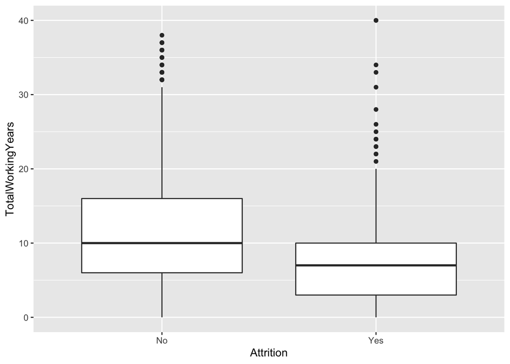

```r
ggplot(attrition, aes(Attrition, TotalWorkingYears)) +
  geom_boxplot()
```

```r
t.test(DistanceFromHome ~ Attrition, data = attrition)
```

```
##
##  Welch Two Sample t-test
##
## data:  DistanceFromHome by Attrition
## t = -2.8882, df = 322.72, p-value = 0.004137
## alternative hypothesis: true difference in means between group No and group Yes is not equal to 0
## 95 percent confidence interval:
##  -2.8870025 -0.5475146
## sample estimates:
##  mean in group No mean in group Yes
##          8.915653         10.632911
```

Check class balance:

```r
attrition %>% pull(Attrition) %>% table()
```

```
## .
##   No  Yes
## 1233  237
```

```r
table(attrition$Attrition) # base R
```

```
##
##   No  Yes
## 1233  237
```

Create a balanced dataset with the same number of observations in both classes

```r
attr_No <- attrition %>%
  filter(Attrition == "No") %>%
  sample_n(size = 237)

attr_Yes <- attrition %>%
  filter(Attrition == "Yes")

attr <- rbind(attr_No, attr_Yes)

# transform outcome to numeric 0-1
nattr <- attr %>%
  mutate(Y = as.numeric(Attrition) - 1) %>%
  select(Y, TotalWorkingYears)
```

## Classification: linear regression?

Plot linear regression line, change the threshold

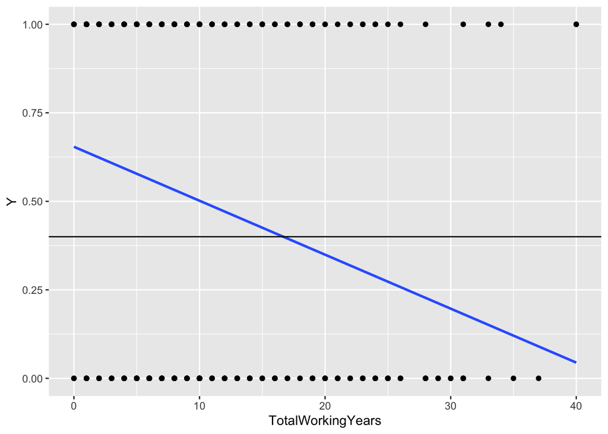

```r
ggplot(nattr, aes(x = TotalWorkingYears, y = Y)) +
  geom_point() +
  geom_smooth(method = "lm", se = FALSE) +
  geom_hline(yintercept = .4) # or e.g. mean(nattr$Y)
```

Problems:

- Can predict outside 0-1 range
- Not directly interpretable as probabilities

### Thresholding ideas

Choose a threshold/cutoff value for predictor $X$, say $c$, and then classify

- $\hat Y = 1$ if $X \geq c$
- $\hat Y = 0$ otherwise

Or if the association is negative, change the sign

As we vary $c$, we trade-off between kinds of errors: false positives and false negatives

In the simple case with thresholding one predictor, the classification/decision rules are all equivalent whether we use linear regression or logistic regression

For **multiple** regression–when we have more predictors–we can then transform a numeric prediction from the model $\hat Y$ to a classification by using a threshold rule on the scale of the predictions (instead of on the scale of one predictor as before)

- $\hat Y = 1$ if $x^T \hat \beta \geq c$
- $\hat Y = 0$ otherwise

## Logistic regression

```r
model_glm <- glm(Y ~ TotalWorkingYears, data = nattr, family = "binomial")
summary(model_glm)
```

```
##
## Call:
## glm(formula = Y ~ TotalWorkingYears, family = "binomial", data = nattr)
##
## Deviance Residuals:
##     Min       1Q   Median       3Q      Max
## -1.4668  -1.1752   0.1798   1.0962   2.0613
##
## Coefficients:
##                   Estimate Std. Error z value Pr(>|z|)
## (Intercept)        0.65878    0.15892   4.145 3.39e-05 ***
## TotalWorkingYears -0.06640    0.01331  -4.989 6.08e-07 ***
## ---
## Signif. codes:  0 '***' 0.001 '**' 0.01 '*' 0.05 '.' 0.1 ' ' 1
##
## (Dispersion parameter for binomial family taken to be 1)
##
##     Null deviance: 657.10  on 473  degrees of freedom
## Residual deviance: 628.99  on 472  degrees of freedom
## AIC: 632.99
##
## Number of Fisher Scoring iterations: 4
```

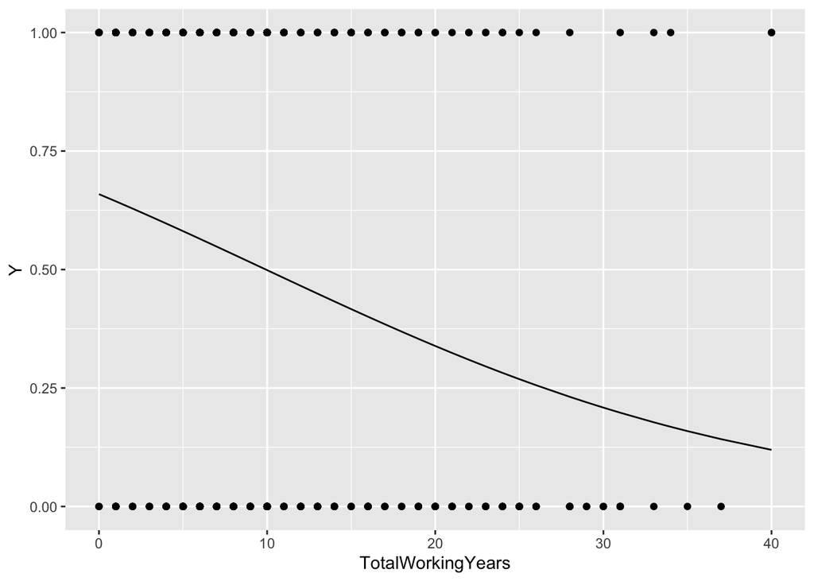

```r
augment(model_glm, type.predict = "response") %>%
  ggplot(aes(TotalWorkingYears, Y)) +
  geom_point() +
  geom_line(aes(y = .fitted))
```

### Modeling assumption

$$\text{logit} P(Y = 1|X) = \beta_0 + \beta_1 X$$

$$P(Y = 1|X) = \frac{e^{\beta_0 + \beta_1 X}}{1 + e^{\beta_0 + \beta_1 X}}$$

### Interpreting coefficients

```r
exp(coef(model_glm))
```

```
##       (Intercept) TotalWorkingYears
##         1.9324296         0.9357545
```

### Inference

```r
exp(confint(model_glm))
```

```
##                       2.5 %    97.5 %
## (Intercept)       1.4200225 2.6496102
## TotalWorkingYears 0.9109235 0.9598299
```

Model evaluation measures

```r
glance(model_glm)
```

```
## # A tibble: 1 × 8
##   null.deviance df.null logLik   AIC   BIC deviance df.residual  nobs
##           <dbl>   <int>  <dbl> <dbl> <dbl>    <dbl>       <int> <int>
## 1          657.     473  -314.  633.  641.     629.         472   474
```

Diagnostic plots: can do this but less common

(Warning: residual plots almost always show “patterns”, can’t be interpreted the same way as for linear regression)